# Tutorial - 1 - Deep Learning

# Task-1 : Explore the Fisher’s linear discriminant analysis (LDA)

1. Error probability of class ‘1’ is the estimation of the function $\Phi$, which is the Cumulative Distribution Function. $\Phi = \frac{\hat{u}_0}{\sqrt{\hat{v}_0}}$

```r
rm(list=ls())
library(MASS)
library(ggplot2)

#-- Compute the model of class 1 and class 0.
n_0 = 1000
n_1 = 1000
Q = matrix(c(1,1,1,4), nrow = 2, byrow = TRUE)
class_0 = mvrnorm(n_0, c(0,0), sqrt(Q))
class_1 = mvrnorm(n_1, c(1,1), sqrt(Q))

n = n_0 + n_1
d = 2
pi_0 = pi_1 = 0.5

#-- Compute the common covariance matrix as specified in the course
S = (1/(n-2))*cov(class_1)+cov(class_0)

delta_hat_sq = ((n - d -1)/n)*t(colMeans(class_1) - colMeans(class_0)) %*% solve(S) %*% (colMeans(class_1) - colMeans(class_0)) - (n+2)*d/(n_0*n_1)

v_hat_0 = (1/(1-(d/n))**2)*(delta_hat_sq + d/(n*pi_0*pi_1))
u_hat_0 = -delta_hat_sq/(2*(1-d/n))
alfa = u_hat_0/sqrt(v_hat_0)

#-- Compute the error rate (approx 28%)
estimated = pnorm(alfa)
estimated
```

```
          [,1]
[1,] 0.3102463
```

2. Build a LDA function to compute the error rate over a simulation of 2000 draws and compare it against the empirical error rate

```r
estimated = 0
n_0 = 10000
n_1 = 10000
n = n_0 + n_1
for (i in 1:2000){
  class_0 = mvrnorm(n_0, c(0,0), sqrt(Q))
  class_1 = mvrnorm(n_1, c(1,1), sqrt(Q))
  S = (1/(n-2))*cov(class_1)+cov(class_0)
  delta_hat_sq = ((n - d -1)/n)*t(colMeans(class_1) - colMeans(class_0)) %*% solve(S) %*% (colMeans(class_1) - colMeans(class_0)) - (n+2)*d/(n_0*n_1)
  v_hat_0 = (1/(1-(d/n))**2)*(delta_hat_sq + d/(n*pi_0*pi_1))
  u_hat_0 = -delta_hat_sq/(2*(1-d/n))
  alfa = u_hat_0/sqrt(v_hat_0)
  estimated[i] = pnorm(alfa)
}
estimated[1:5]
```

```
[1] 0.3121830 0.3014643 0.3063280 0.3112845 0.3104271
```

```r
#-- Build LDA and compute the error over 2000 draws

error = 0
for (i in 1:2000){
  #-- Generate data for classes 0 and 1
  class_0 = mvrnorm(n_0, c(0,0), sqrt(Q))
  class_1 = mvrnorm(n_1, c(1,1), sqrt(Q))

  #-- Build the data frame
  df_0 <- as.data.frame(class_0)
  df_1 <- as.data.frame(class_1)
  names(df_0)[1] = "X1"
  names(df_0)[2] = "X2"
  names(df_1)[1] = "X1"
  names(df_1)[2] = "X2"
  df_class_0 = cbind(df_0, Y = 0)
  df_class_1 = cbind(df_1, Y = 1)
  df = rbind(df_class_0, df_class_1)

  #-- Randomly shuffle
  rows <- sample(nrow(df))
  df <- df[rows,]
  row.names(df) <- NULL

  #-- build lda and get predictions
  model <- lda(Y~., data = df)
  Y_pred = predict(model, df)$class
  Y_true = df$Y
  error[i] = mean(Y_pred != Y_true)

}
error[1:5]
```

```
[1] 0.31335 0.30640 0.30715 0.30845 0.30695
```

3. Compare these two distributions of error and verify their normality visually

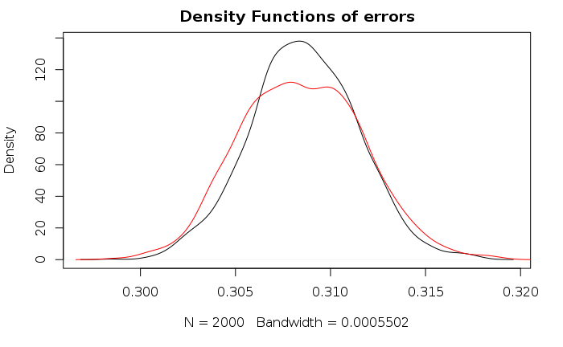

```r
#-- Plot the density function to verify normality
plot(density(estimated), main = "Density Functions of errors")
lines(density(error), col = 'red')
```

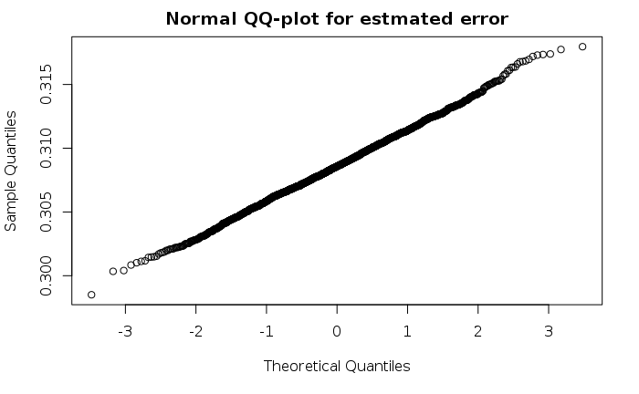

```r
#-- plot qqnorm plot to verify normality (should be close to linear)
qqnorm(estimated, main = "Normal QQ-plot for estmated error")
```

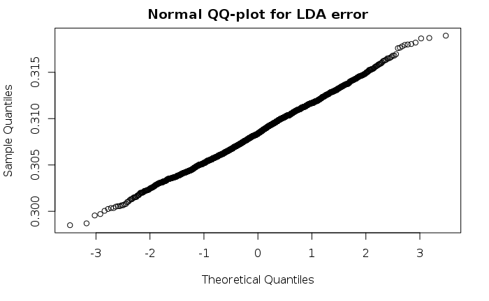

```r
qqnorm(error, main = "Normal QQ-plot for LDA error")
```

```r
#-- Shapiro-Wilk Normality Test (check that p-value is less than 0.5)
shapiro.test(estimated)
```

```
    Shapiro-Wilk normality test

data:  estimated
W = 0.99904, p-value = 0.3747
```

```r
shapiro.test(error)
```

```
    Shapiro-Wilk normality test

data:  error
W = 0.99794, p-value = 0.0115
```

4. repeat the experiment in a,b,c for the remaining two models

```r
#-- Model 2

estimated_2 = 0
error_2 = 0
n_0 = 10000
n_1 = 10000
n = n_0 + n_1
Q = matrix(c(1,1.1,1.35,3), nrow = 2, byrow = TRUE)

for (i in 1:500){
  class_0 = mvrnorm(n_0, c(0,0), sqrt(Q))
  class_1 = mvrnorm(n_1, c(1.4,2.1), sqrt(Q))
  S = (1/(n-2))*cov(class_1)+cov(class_0)
  delta_hat_sq = ((n - d -1)/n)*t(colMeans(class_1) - colMeans(class_0)) %*% solve(S) %*% (colMeans(class_1) - colMeans(class_0)) - (n+2)*d/(n_0*n_1)
  v_hat_0 = (1/(1-(d/n))**2)*(delta_hat_sq + d/(n*pi_0*pi_1))
  u_hat_0 = -delta_hat_sq/(2*(1-d/n))
  alfa = u_hat_0/sqrt(v_hat_0)
  estimated_2[i] = pnorm(alfa)

  #-- Build the data frame
  df_0 <- as.data.frame(class_0)
  df_1 <- as.data.frame(class_1)
  names(df_0)[1] = "X1"
  names(df_0)[2] = "X2"
  names(df_1)[1] = "X1"
  names(df_1)[2] = "X2"
  df_class_0 = cbind(df_0, Y = 0)
  df_class_1 = cbind(df_1, Y = 1)
  df = rbind(df_class_0, df_class_1)

  #-- Randomly shuffle
  rows <- sample(nrow(df))
  df <- df[rows,]
  row.names(df) <- NULL

  #-- build lda and get predictions
  model <- lda(Y~., data = df)
  Y_pred = predict(model, df)$class
  Y_true = df$Y
  error_2[i] = mean(Y_pred != Y_true)
}
```

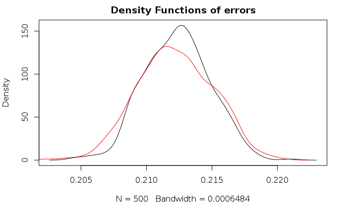

```r
#-- plot density functions
plot(density(estimated_2), main = "Density Functions of errors")
lines(density(error_2), col = 'red')
```

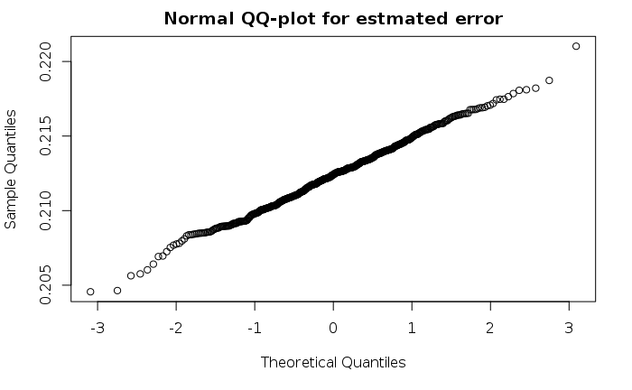

```r
#-- plot qqnorm plot to verify normality (should be close to linear)
qqnorm(estimated_2, main = "Normal QQ-plot for estmated error")
```

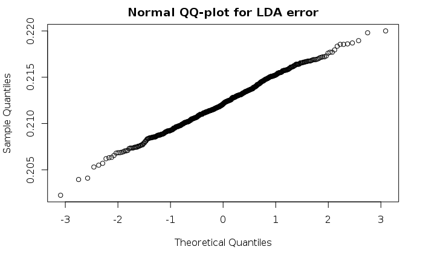

```r
qqnorm(error_2, main = "Normal QQ-plot for LDA error")
```

```r
#-- Model 3

estimated_3 = 0
error_3 = 0
n_0 = 10000
n_1 = 10000
n = n_0 + n_1
Q = matrix(c(1,2.1,2.7,9), nrow = 2, byrow = TRUE)

for (i in 1:500){
  class_0 = mvrnorm(n_0, c(0,0), sqrt(Q))
  class_1 = mvrnorm(n_1, c(3,2.5), sqrt(Q))
  S = (1/(n-2))*cov(class_1)+cov(class_0)
  delta_hat_sq = ((n - d -1)/n)*t(colMeans(class_1) - colMeans(class_0)) %*% solve(S) %*% (colMeans(class_1) - colMeans(class_0)) - (n+2)*d/(n_0*n_1)
  v_hat_0 = (1/(1-(d/n))**2)*(delta_hat_sq + d/(n*pi_0*pi_1))
  u_hat_0 = -delta_hat_sq/(2*(1-d/n))
  alfa = u_hat_0/sqrt(v_hat_0)
  estimated_3[i] = pnorm(alfa)

  #-- Build the data frame
  df_0 <- as.data.frame(class_0)
  df_1 <- as.data.frame(class_1)
  names(df_0)[1] = "X1"
  names(df_0)[2] = "X2"
  names(df_1)[1] = "X1"
  names(df_1)[2] = "X2"
  df_class_0 = cbind(df_0, Y = 0)
  df_class_1 = cbind(df_1, Y = 1)
  df = rbind(df_class_0, df_class_1)

  #-- Randomly shuffle
  rows <- sample(nrow(df))
  df <- df[rows,]
  row.names(df) <- NULL

  #-- build lda and get predictions
  model <- lda(Y~., data = df)
  Y_pred = predict(model, df)$class
  Y_true = df$Y
  error_3[i] = mean(Y_pred != Y_true)
}
```

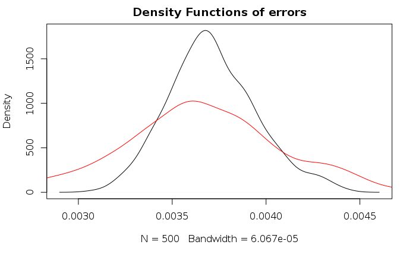

```r
#-- plot density functions
plot(density(estimated_3), main = "Density Functions of errors")
lines(density(error_3), col = 'red')
```

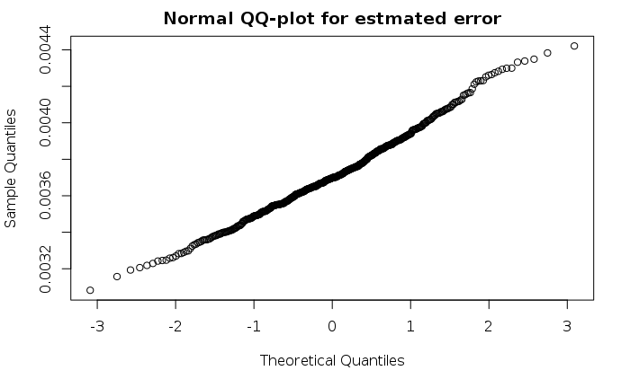

```r
#-- plot qqnorm plot to verify normality (should be close to linear)
qqnorm(estimated_3, main = "Normal QQ-plot for estmated error")
```

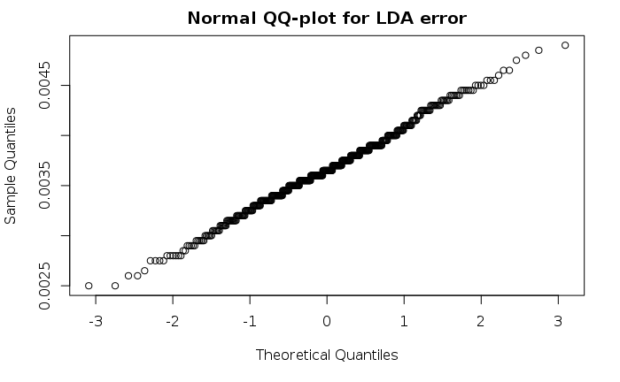

```r
qqnorm(error_3, main = "Normal QQ-plot for LDA error")
```

Explanation : The more variance we have, the harder it becomes to estimate the probability error. This is due to the fact that the points are more sparse now. Which means that one single circle would not be enough to catch all the observations of class_1 and class_0.

# Task-2 : Find optimal k for the k-nearest neighbors classifier (kNN)

## Model - 1

Note : KNN is not immune to scaling. We should scale variables before applying KNN on real data. Here, however, the data is already normalized.

```r
#-- Build Model 1 according to the described mean and covariance matrix with a total of 2000 observations
library(MASS)
set.seed(1)
n = 1000
Q = matrix(c(1,1,1,4), nrow = 2, byrow = TRUE)
class_0 = mvrnorm(n, c(0,0), sqrt(Q))
class_1 = mvrnorm(n, c(1,1), sqrt(Q))
df_class_0 = cbind(class_0, Y = 0)
df_class_1 = cbind(class_1, Y = 1)
df = as.data.frame(rbind(df_class_0, df_class_1))

#-- Randomly shuffle
rows = sample(nrow(df))
df = df[rows,]
row.names(df) = NULL
head(df)
```

|  | V1 | V2 | Y |
| --- | --- | --- | --- |
| 1 | -0.98716503 | -1.9961887 | 0 |
| 2 | 0.84342778 | 0.9769125 | 0 |
| 3 | -0.65278697 | -2.1070798 | 1 |
| 4 | -0.07872612 | 0.2300295 | 0 |
| 5 | 1.22318208 | 1.4188922 | 1 |
| 6 | 0.14314468 | 1.6395531 | 1 |

```r
#-- Test train split and building the KNN classifier
train_index = sample(nrow(df), 7*nrow(df)/10)
df_train = df[train_index,]
df_test = df[-train_index,]

#-- KNN algorithm with fixed k and test error without cross validation
library(class)

Y_pred = knn(train = df_train,
             test  = df_test,
             cl    = df_train$Y,
             k     = 50)
Y_true = df_test$Y
cat("The error rate is : ", mean(Y_true != Y_pred)*100, "%")
```

```
The error rate is :  0.8333333 %
```

Now to do cross validation using odd K’s. The reason we choose odd K’s is because we only have two classes to predict from. Therefore, using odd k’s would avoid having ties.

**PS : A tie is when a machine cannot decide the class of the outcome due to similar number of votes. If we have two classes and 4 neighbors, two neighbors can have the outcome 0 and two others can have the outcome 1 which would result in a tie.**

```r
#-- Using the leave-one-out cross validation (jackknife) to determine the optimal k for odd numbers between 1 and half the sample size
k_to_try = seq(1, nrow(df)/10, by=2)
error_cv = rep(0, length(k_to_try))

for (i in seq_along(k_to_try)) {
  Y_pred = as.numeric(knn.cv(train = df[,1:2],
                              cl= df$Y,
                              k = k_to_try[i]))-1
  error_cv[i] = mean(Y_pred != df$Y)
}
```

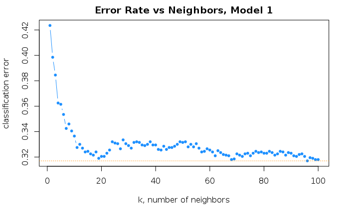

```r
# plot error vs choice of k
plot(error_cv, type = "b", col = "dodgerblue", cex = 1, pch = 20,
     xlab = "k, number of neighbors",
     ylab = "classification error",
     main = "Error Rate vs Neighbors, Model 1")
# add line for min error seen
abline(h = min(error_cv), col = "darkorange", lty = 3)
```

```r
#-- which value of k gives the minimum cross validation?
min(error_cv)
```

```
[1] 0.317
```

```r
k_to_try[which(error_cv == min(error_cv))]
```

```
[1] 191
```

## Model - 2

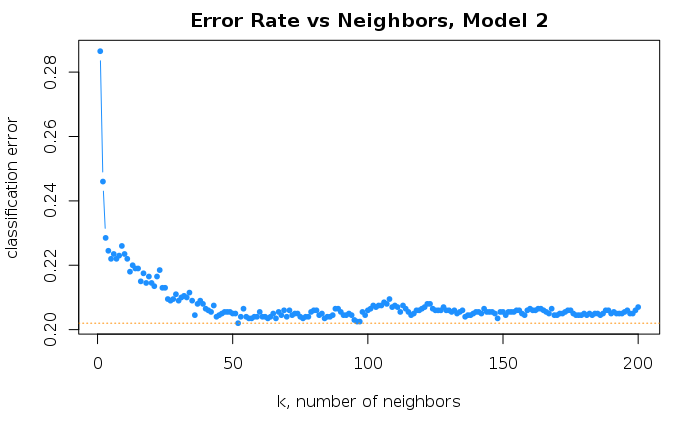

```r
#-- Create model
n = 1000
Q = matrix(c(1,1.1,1.35,3), nrow = 2, byrow = TRUE)
class_0 = mvrnorm(n, c(0,0), sqrt(Q))
class_1 = mvrnorm(n, c(1.4,2.1), sqrt(Q))
df_class_0 = cbind(class_0, Y = 0)
df_class_1 = cbind(class_1, Y = 1)
df = as.data.frame(rbind(df_class_0, df_class_1))

#-- Randomly shuffle
rows <- sample(nrow(df))
df <- df[rows,]
row.names(df) <- NULL

#-- cross validation of the knn classifier
k_to_try = seq(1, nrow(df)/5, by=2)
error_cv_2 = rep(0, length(k_to_try))

for (i in seq_along(k_to_try)) {
  Y_pred = as.numeric(knn.cv(train = df[,1:2],
                              cl= df$Y,
                              k = k_to_try[i]))-1
  error_cv_2[i] = mean(Y_pred != df$Y)
}

#-- plot error vs choice of k
plot(error_cv_2, type = "b", col = "dodgerblue", cex = 1, pch = 20,
     xlab = "k, number of neighbors",
     ylab = "classification error",
     main = "Error Rate vs Neighbors, Model 2")
# add line for min error seen
abline(h = min(error_cv_2), col = "darkorange", lty = 3)
```

```r
#-- which value of k gives the minimum cross validation?
min(error_cv_2)
```

```
[1] 0.202
```

```r
k_to_try[which(error_cv_2 == min(error_cv_2))]
```

```
[1] 103
```

## Model - 3

```r
#-- Create model
n = 1000
Q = matrix(c(1,2.1,2.7,9), nrow = 2, byrow = TRUE)
class_0 = mvrnorm(n, c(0,0), sqrt(Q))
class_1 = mvrnorm(n, c(3,2.5), sqrt(Q))
df_class_0 = cbind(class_0, Y = 0)
df_class_1 = cbind(class_1, Y = 1)
df = as.data.frame(rbind(df_class_0, df_class_1))

#-- Randomly shuffle
rows <- sample(nrow(df))
df <- df[rows,]
row.names(df) <- NULL

#-- cross validation of the knn classifier
k_to_try = seq(1, nrow(df)/10, by=2)
error_cv_3 = rep(0, length(k_to_try))

for (i in seq_along(k_to_try)) {
  Y_pred = as.numeric(knn.cv(train = df[,1:2],
                              cl= df$Y,
                              k = k_to_try[i]))-1
  error_cv_3[i] = mean(Y_pred != df$Y)
}
```

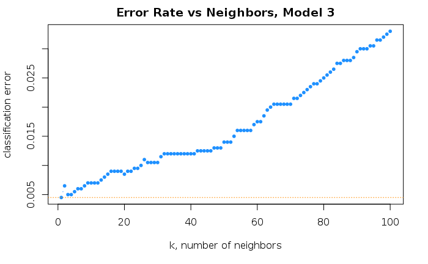

```r
#-- plot error vs choice of k
plot(error_cv_3, type = "b", col = "dodgerblue", cex = 1, pch = 20,
     xlab = "k, number of neighbors",
     ylab = "classification error",
     main = "Error Rate vs Neighbors, Model 3")
# add line for min error seen
abline(h = min(error_cv_3), col = "darkorange", lty = 3)
```

```r
#-- which value of k gives the minimum cross validation?
min(error_cv_3)
```

```
[1] 0.0045
```

```r
k_to_try[which(error_cv_3 == min(error_cv_3))]
```

```
[1] 1
```

# Task - 3 - Classification Trees

```r
#-- Simulate data (100 observations, 50 each for each class)
n = 50
Q = matrix(c(1,1,1,4), nrow = 2, byrow = TRUE)
class_0 = mvrnorm(n, c(0,0), sqrt(Q))
class_1 = mvrnorm(n, c(1,1), sqrt(Q))
df_class_0 = cbind(class_0, Y = 0)
df_class_1 = cbind(class_1, Y = 1)
df = as.data.frame(rbind(df_class_0, df_class_1))

#-- Randomly shuffle
rows = sample(nrow(df))
df = df[rows,]
row.names(df) = NULL

#-- grow a classification tree
library(rpart)
tree <- rpart(Y~.,
              data = df,
              method = "class")
#summary(tree)
```

Note: when you fit a tree using rpart, the fitting routine automatically performs 10-fold CV and stores the errors for later use.

Using a few packages, we can plot the tree in a more visually appealing way.

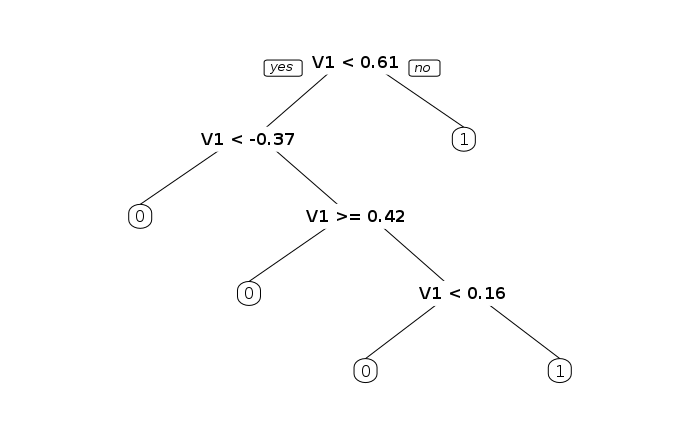

```r
library(rpart.plot)
prp(tree)
```

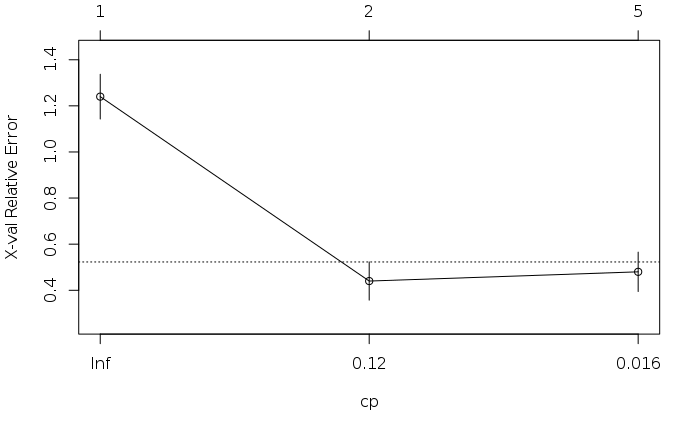

```r
plotcp(tree)
```

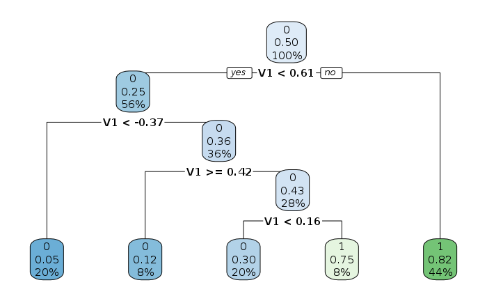

```r
rpart.plot(tree)
```

# Task - 4 - Explore influence of the minimum size of a splittable node in the classification tree

Create a function that generates a dataframe of binary responses Y with two covariates each of which is correlated by means of a normal distribution to an outcome with mean 0 for class 0 and mean 1 for class 1 and a covariance matrix Q.

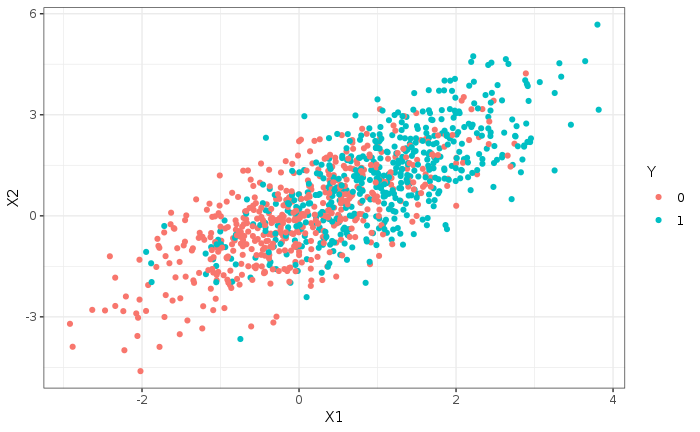

```r
#--  Function to generate data with n observations
gen_bin_data = function(n, m0, m1, A, B) {
  #-- Generate data
  library(MASS)
  class_0 = mvrnorm(n/2, m0, sqrt(A))
  class_1 = mvrnorm(n/2, m1, sqrt(B))
  df_class_0 = cbind(class_0, Y = 0)
  df_class_1 = cbind(class_1, Y = 1)
  df = as.data.frame(rbind(df_class_0, df_class_1))
  df$Y = as.factor(df$Y)
  names(df)[1] = "X1"
  names(df)[2] = "X2"

  #-- Randomly shuffle
  rows = sample(nrow(df))
  df = df[rows,]
  row.names(df) = NULL
  return(df)
}

#-- Function to calculate prediction error on a classifier
calc_class_err = function(actual, predicted) {
  mean(actual != predicted)
}

#-- Test the data generation function
Q = matrix(c(1,1,1,4), nrow = 2, byrow = TRUE)
test = gen_bin_data(1000,c(0,0), c(1,1), Q, Q)

library(ggplot2)
ggplot(test, aes(x=X1, y=X2, col = Y)) + geom_point() + theme_bw()
```

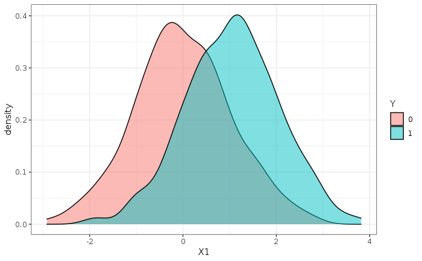

```r
ggplot(test, aes(x=X1, fill = Y)) + geom_density(alpha = 0.5) + theme_bw()
```

```r
#-- Simulate data with a three training sample sizes (100,200 and 500) and one testing sample of size 1000 for model 1
Q = matrix(c(1,1,1,4), nrow = 2, byrow = TRUE)
df_train_1 = gen_bin_data(100,c(0,0), c(1,1), Q, Q)
df_train_2 = gen_bin_data(200,c(0,0), c(1,1), Q, Q)
df_train_3 = gen_bin_data(500,c(0,0), c(1,1), Q, Q)
df_test = gen_bin_data(1000,c(0,0), c(1,1), Q, Q)
```

Grow trees on training data and test errors on testing data with a fixed value of splits.

```r
#-- Build function that grows trees on training data, makes predictions on test data and returns errors
build_tree = function(train_data, test_data, splits) {
  library(rpart)
  tree = rpart(Y~., data = train_data, method = "class", minsplit = splits)
  Y_pred = predict(tree, test_data, type = "class")
  error = calc_class_err(test_data$Y, Y_pred)
  return(list(Tree = tree, classification_error = error))
}
```

```r
#-- Build tree on three training datasets with fixed minsplit of 3 and calculate three errors.
error_1 = build_tree(df_train_1, df_test, 3)[[2]]
error_2 = build_tree(df_train_2, df_test, 3)[[2]]
error_3 = build_tree(df_train_3, df_test, 3)[[2]]
c(error_1,error_2,error_3)
```

```
[1] 0.394 0.341 0.294
```

As expected, it seems that the bigger the training size, the better the performance. Lets now include the effect of minimum number of splits into account. For that we will create a function that takes test and train data as inputs and return a vector containing erros based on the length of the grid to consider for the splits.

```r
#-- function that returns a vector of errors for a grid if splits
build_tree_split = function(train_data, test_data, grid) {
  library(rpart)
  error = rep(0, length(grid))
  for (i in seq_along(grid)) {
    tree = rpart(Y~., data = train_data, method = "class", minsplit = grid[i])
    Y_pred = predict(tree, test_data, type = "class")
    error[i] = calc_class_err(test_data$Y, Y_pred)
  }
  return(error)
}
```

Lets iterate over this process a 100 times for repeatability and compute the errors for the three sample sizes. We should get a matrix of 100 rows and 10 columns. Each column corresponds to a certain split in the grid. Then plot three charts containing 10 boxplots each to compare errors of all 10 splits for each of the 3 training sample sizes.

```r
#-- loop 100 times over each of the three training sets

rep_tree_error = function(train_size, test_size, replicates) {

  #-- Define error matrix and the loop to replicate
  all_errors = matrix(0, ncol = 10, nrow = 100)
  for (k in 1:replicates){

    #-- Generate train and test data
    df_train = gen_bin_data(train_size,c(0,0), c(1,1), Q, Q)
    df_test = gen_bin_data(test_size,c(0,0), c(1,1), Q, Q)

    #-- Choose grids. Here we choose n as the length of class 1
    splits = round(seq(1, nrow(df_train)/2, length.out = 10))

    #-- Grow trees on training data with respect to the grid
    all_errors[k,] = build_tree_split(df_train, df_test, splits)
  }

  #-- rename columns of the matrix according to the number of splits
  error_names = rep(0, ncol(all_errors))
  for (i in 1:length(splits)){
    error_names[i] = paste(splits[i], "splits")
  }
  colnames(all_errors) = error_names
  return(all_errors)
}
```

Now we apply the above function to all three training sets and plot the results in three different charts and explore results

```r
#-- Compute three error matrices for three training sets of sizes 100, 200 and 500. replication size is 100 and test size sample is 1000
test_size = 1000
N = 100
sample_1 = rep_tree_error(100, test_size, N)
sample_2 = rep_tree_error(200, test_size, N)
sample_3 = rep_tree_error(500, test_size, N)
```

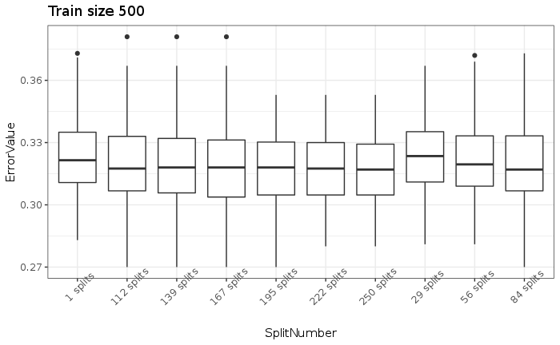

```r
#-- transorming data into data frames and plotting box plots
library(tidyr)
df_3 = gather(as.data.frame(sample_3), SplitNumber, ErrorValue)
df_2 = gather(as.data.frame(sample_2), SplitNumber, ErrorValue)
df_1 = gather(as.data.frame(sample_1), SplitNumber, ErrorValue)

ggplot(df_3, aes(x=SplitNumber, y=ErrorValue)) +
    geom_boxplot() + theme_bw() + theme(axis.text.x = element_text(angle = 45)) + ggtitle("Train size 500")
```

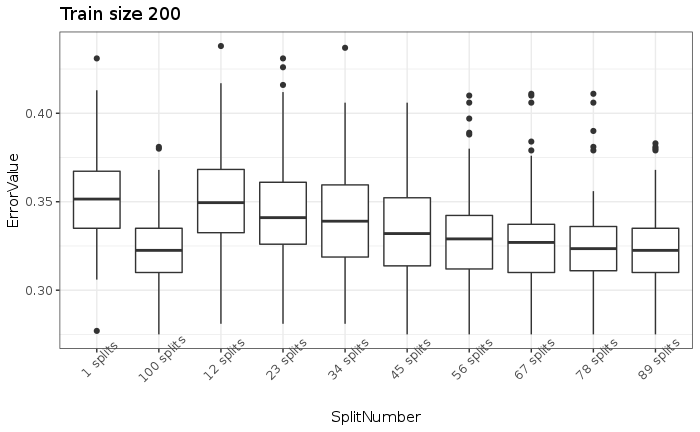

```r
ggplot(df_2, aes(x=SplitNumber, y=ErrorValue)) +
    geom_boxplot() + theme_bw() + theme(axis.text.x = element_text(angle = 45)) + ggtitle("Train size 200")
```

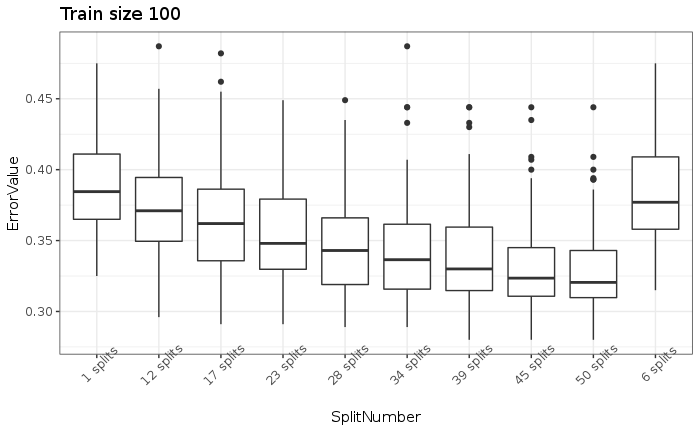

```r
ggplot(df_1, aes(x=SplitNumber, y=ErrorValue)) +
    geom_boxplot() + theme_bw() + theme(axis.text.x = element_text(angle = 45)) + ggtitle("Train size 100")
```

```r
print(min(colMeans(sample_1)))
```

```
[1] 0.32922
```

```r
which.min(colMeans(sample_1))
```

```
50 splits
       10
```

```r
print(min(colMeans(sample_2)))
```

```
[1] 0.32354
```

```r
which.min(colMeans(sample_2))
```

```
100 splits
        10
```

```r
print(min(colMeans(sample_3)))
```

```
[1] 0.31764
```

```r
which.min(colMeans(sample_3))
```

```
250 splits
        10
```

Interpretation: for a higher train size we notice that minimum number of splits do not have any effect on the overall classification error as opposed to the first two samples that are considerably smaller. We also notice no significant improvement in performance when increasing the training sample.

```r
#-- Comparing with LDA only on sample_3.
replicated_lda = function(train_size, test_size, replicas){
  lda_error = rep(0, replicas)
  for (k in 1:replicas) {

    #-- Generate train and test data
    df_train = gen_bin_data(train_size,c(0,0), c(1,1), Q, Q)
    df_test = gen_bin_data(test_size,c(0,0), c(1,1), Q, Q)

    #-- build LDA
    model = lda(Y~., data = df_train_3)
    Y_pred = predict(model, df_test)$class
    lda_error = calc_class_err(df_test$Y, Y_pred)
    return(min(lda_error))
  }
}

data.frame(LDA_Error = replicated_lda(500,1000,100), Optimal_Tree_Split = min(colMeans(sample_3)))
```

| LDA_Error | Optimal_Tree_Split |
| --- | --- |
| 0.288 | 0.31764 |

# Task - 5 - Bagged LDA and Bagged Trees

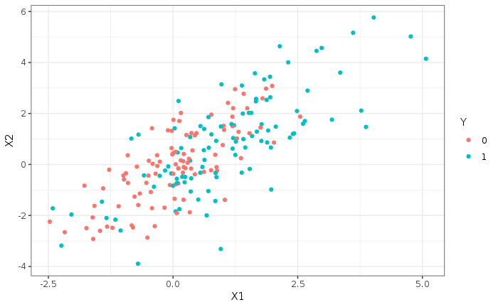

```r
#-- Generate data from setting 2
A = matrix(c(4,4,4,16), nrow = 2, byrow = TRUE)

df_train = gen_bin_data(200,c(0,0), c(1,1), Q, A)
df_test = gen_bin_data(10000,c(0,0), c(1,1), Q, A)

ggplot(df_train, aes(x=X1, y=X2, col = Y)) + geom_point() + theme_bw()
```

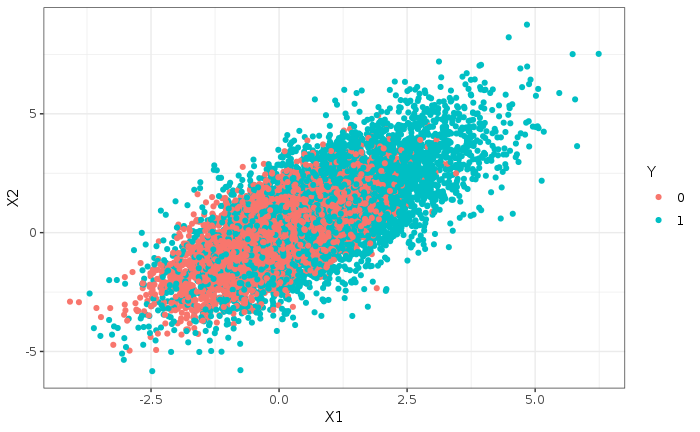

```r
ggplot(df_test, aes(x=X1, y=X2, col = Y)) + geom_point() + theme_bw()
```

```r
library(ipred)
grid = seq(10,500, length.out = 50)
bagged_error = rep(0, length(grid))

for (i in seq_along(grid)) {
  bagged_tree = bagging(Y~., data = df_train, nbagg = grid[i], coob = TRUE, control = rpart.control(minsplit = 1))
  Y_pred = predict(bagged_tree, newdata = df_test)
  bagged_error[i] = calc_class_err(df_test$Y, Y_pred)
}
bagged_error
```

```
 [1] 0.3659 0.3648 0.3589 0.3667 0.3593 0.3608 0.3595 0.3591 0.3607 0.3610 0.3626 0.3646 0.3524 0.3576 0.3571 0.3576 0.3624 0.3582 0.3575
[20] 0.3582 0.3600 0.3573 0.3607 0.3557 0.3609 0.3608 0.3605 0.3572 0.3594 0.3579 0.3618 0.3568 0.3589 0.3587 0.3574 0.3597 0.3612 0.3608
[39] 0.3600 0.3594 0.3611 0.3609 0.3586 0.3556 0.3568 0.3592 0.3558 0.3612 0.3566 0.3588
```

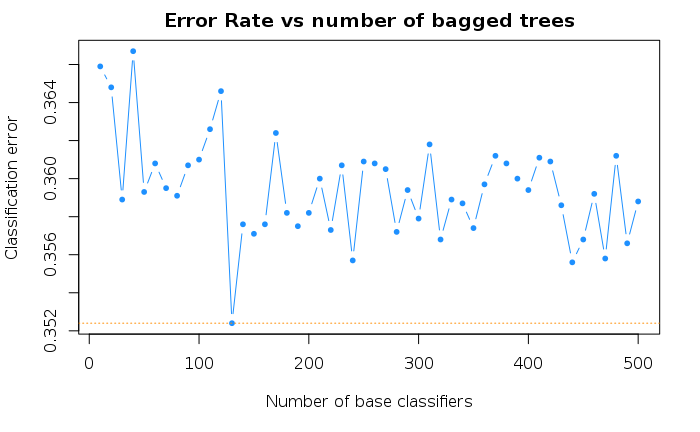

```r
plot(grid, bagged_error, type = "b", col = "dodgerblue", cex = 1, pch = 20,
     xlab = "Number of base classifiers",
     ylab = "Classification error",
     main = "Error Rate vs number of bagged trees")
abline(h = min(bagged_error), col = "darkorange", lty = 3)
```

```r
min(bagged_error)
```

```
[1] 0.3524
```

```r
grid[which.min(bagged_error)]
```

```
[1] 130
```

```r
build_tree(df_train, df_test, 1)$classification_error
```

```
[1] 0.37
```

# Task - 6 - Random forest classifier on spam data

1. Exploring influence of the number of randomly chosen variables at each node on the performance of the random forest. For this part, we use the error on the test set.

```r
#-- Load data and spit it in test train sets
library(kernlab)
data(spam)
train_index = sample(1:nrow(spam), 2300)
spam_train = spam[train_index,]
spam_test = spam[-train_index,]
```

**IMPORTANT NOTE:** The main difference between bagging trees and random forests is that Random forests help to reduce tree correlation by injecting more randomness into the tree-growing process. Simply bagging trees can result in tree correlation that limits the effect of variance reduction.

The Hyperparameters to be considered in this task are : 1. The number of trees in the forest 2. The number of features to consider at any given split: (also called $m_{try}$)

```r
#-- Build random forest classifier and looping over a grid of trees and a number of variables
build_forest = function(df_train, df_test, max_tree, m_try){

  library(randomForest)
  trees = 1:max_tree
  forest_error = matrix(0, nrow = length(trees), ncol = length(m_try))

  #-- loop to iterate over number of trees to grow in the forest
  for (i in seq_along(trees)) {
    #-- loop to iterate over the sequence of variables to be considered at each split
    for (k in seq_along(m_try)) {
      forest = randomForest(type~., data = df_train, ntree = trees[i], mtry = m_try[k])
      Y_pred = predict(forest, newdata = df_test)
      forest_error[i,k] = calc_class_err(df_test$type, Y_pred)
    }
  }

  #-- rename columns of the matrix according to the number of splits
  error_names = rep(0, ncol(forest_error))
  for (i in 1:length(m_try)){
    error_names[i] = paste(m_try[i], "Variables")
  }
  colnames(forest_error) = error_names
  return(forest_error)
}

#-- test the function for 50 trees and 1,7 and 35 variables
fores_error = build_forest(spam_train, spam_test, 50, c(1,7,35))
```

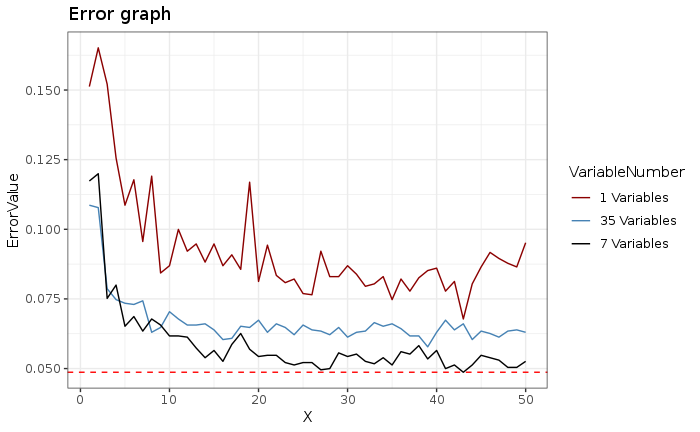

```r
#-- some data manipulation and plotting the error
library(tidyverse)
t = as.data.frame(cbind(fores_error, X = 1:nrow(fores_error)))
error_df = gather(t, VariableNumber, ErrorValue, -X)

ggplot(error_df, aes(x=X, y=ErrorValue, col = VariableNumber )) +
  geom_line() + theme_bw() + ggtitle("Error graph") +
  scale_color_manual(values = c("darkred", "steelblue", "black")) +
  geom_hline(yintercept=min(fores_error), linetype="dashed", color = "red")
```

```r
t[which.min(t$`7 Variables`),c(2,4)]
```

|  | 7 Variables | X |
| --- | --- | --- |
| 43 | 0.04867449 | 43 |

2. Repeating the first question but with out of bag error for the random forest. In order to do so, we use the full data as input and use the argument subset = training indices of the data we would like to use to train the classifier. *We can make sure that it is the out of bag error by calling the classifier and check its output*

```r
#-- Build random forest and see the OOB error (NOT THE TEST ERROR)
build_forest_OOB = function(df, train, max_tree, m_try){

  library(randomForest)
  oob_err = matrix(0, ncol = length(m_try), nrow = max_tree)

  #-- loop to iterate over the sequence of variables to be considered at each split and calculate OOB error for each
  for (k in seq_along(m_try)) {
    forest = randomForest(type~., data = df, ntree = max_tree, mtry = m_try[k], subset = train)
    oob_err[,k] = forest$err.rate[,1]
  }

  #-- rename columns of the matrix according to the number of splits
  error_names = rep(0, ncol(oob_err))
  for (i in 1:length(m_try)){
    error_names[i] = paste(m_try[i], "Variables")
  }
  colnames(oob_err) = error_names
  return(oob_err)
}

#-- test the function for 50 trees and 1,7 and 35 variables
forest_oob = build_forest_OOB(spam, train_index, 50, c(1,7,35))
```

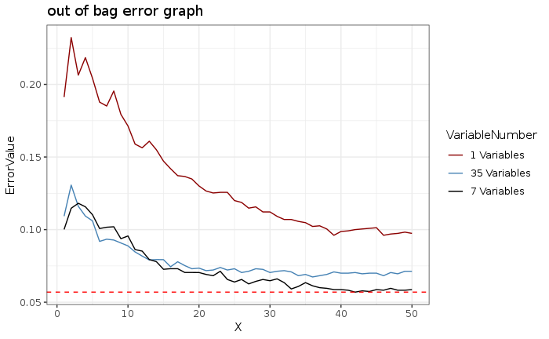

```r
#-- plot the error according to all the randomly chosen number of variables
t_2 = as.data.frame(cbind(forest_oob, X = 1:nrow(forest_oob)))
OOB_error_df = gather(t_2, VariableNumber, ErrorValue, -X)

ggplot(OOB_error_df, aes(x=X, y=ErrorValue, col = VariableNumber )) +
  geom_line() + theme_bw() + ggtitle("out of bag error graph") +
  scale_color_manual(values = c("darkred", "steelblue", "black")) +
  geom_hline(yintercept=min(forest_oob), linetype="dashed", color = "red")
```

```r
t_2[which.min(t_2$`7 Variables`),c(2,4)]
```

|  | 7 Variables | X |
| --- | --- | --- |
| 42 | 0.05695652 | 42 |

In both cases, it seems that the minimum error corresponds to 7 variables which is the number of variables randomly drawn by default.

```r
#-- Compare OOB error and test error
data.frame(OOB_Error = round(t_2[which.min(t_2$`7 Variables`),c(2)],4)*100 , Test_Error = round(t[which.min(t$`7 Variables`),c(2)],4)*100)
```

| OOB_Error | Test_Error |
| --- | --- |
| 5.7 | 4.87 |

It seems that the Test error is slightly better than the OOB but not significantly better.

# Task - 7 - Compare performance of classifiers on pima data

```r
rm(list=ls())

#-- load library that contains data
library(MASS)

#-- load and merge data into one dataset
data("Pima.tr")
data("Pima.te")
df = rbind(Pima.te, Pima.te)
dim(df)
```

```
[1] 664   8
```

```r
head(df)
```

|  | npreg | glu | bp | skin | bmi | ped | age | type |
| --- | --- | --- | --- | --- | --- | --- | --- | --- |
| 1 | 6 | 148 | 72 | 35 | 33.6 | 0.627 | 50 | Yes |
| 2 | 1 | 85 | 66 | 29 | 26.6 | 0.351 | 31 | No |
| 3 | 1 | 89 | 66 | 23 | 28.1 | 0.167 | 21 | No |
| 4 | 3 | 78 | 50 | 32 | 31.0 | 0.248 | 26 | Yes |
| 5 | 2 | 197 | 70 | 45 | 30.5 | 0.158 | 53 | Yes |
| 6 | 5 | 166 | 72 | 19 | 25.8 | 0.587 | 51 | Yes |

```r
sum(is.na(df))
```

```
[1] 0
```

Data seems to contain 664 observations and 8 features including the target variable. We will perform a test train split (250 train and 414 to test)

```r
#-- load file with various useful functions and libraries
source("functions_tutorial_2.R")
library(randomForest)
library(robustbase)
library(class)
N = 100
train_size = 250
lda_error = qda_error = knn_error = rf_error = rep(0,N)

#-- load to repeat the sampling k_times
for (k in 1:N){

  #-- perform a test train split according to the rule specified above
  train_index = sample(1:nrow(df), train_size)
  df_train = df[train_index,]
  df_test = df[-train_index,]

  #-- build lda and predict error
  lda.fit = lda(type~., data = df_train)
  lda.pred = predict(lda.fit, newdata = df_test)$class
  lda_error[k] = calc_class_err(df_test$type, lda.pred)

  #-- build qda and predict error
  qda.fit = qda(type~., data = df_train)
  qda.pred = predict(qda.fit, newdata = df_test)$class
  qda_error[k] = calc_class_err(df_test$type, qda.pred)

  #-- build covMcd and predict error

  #-- knn with restricted odd k's from 1 to 150 using LOOCV. p = 1 for leave p out cv.
  k_to_try = seq(3, 150, by = 2)
  cv_error = rep(0, length(k_to_try))
  for (i in seq_along(k_to_try)) {
    knn.cv.pred = knn.cv(train = df[, !names(df_train) == "type"],
                      cl = df$type,
                      p = 1,
                      k = k_to_try[i])
    cv_error[i] = calc_class_err(df$type, knn.cv.pred)

  }
  best_k = k_to_try[which(cv_error == min(cv_error))]
  knn.pred = knn(train = df_train[,-8],
                 test = df_test[,-8],
                 cl = df_train$type,
                 k = 1)
  knn_error[k] = calc_class_err(df_test$type, knn.pred)

  #-- Random forest classifier
  rf.fit = randomForest(type~., data = df_train)
  rf.pred = predict(rf.fit, newdata = df_test)
  rf_error[k] = calc_class_err(df_test$type, rf.pred)
}

#-- store results in the form of a data frame for better use
df_error = data.frame(lda_error = lda_error, qda_error = qda_error, knn_error = knn_error, rf_error = rf_error)
head(df_error)
```

|  | lda_error | qda_error | knn_error | rf_error |
| --- | --- | --- | --- | --- |
| 1 | 0.2149758 | 0.2198068 | 0.1642512 | 0.1400966 |
| 2 | 0.2367150 | 0.2173913 | 0.1690821 | 0.1207729 |
| 3 | 0.2149758 | 0.2342995 | 0.1835749 | 0.1400966 |
| 4 | 0.2125604 | 0.2270531 | 0.1835749 | 0.1690821 |
| 5 | 0.1787440 | 0.1835749 | 0.1352657 | 0.1159420 |
| 6 | 0.1908213 | 0.1908213 | 0.1835749 | 0.1256039 |

Now that we computed errors with 100 repetitions and built a data frame for all the errors, we will plot them in the form of boxplots to visualize. It seems that the random forest gives the minimum error out of all the classifiers that we tested which is about 13%.

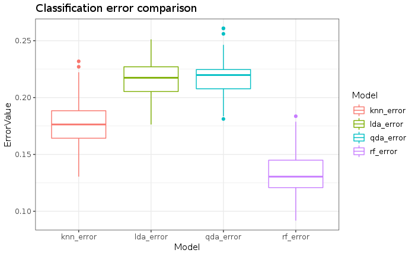

```r
#-- plot boxplots of results using ggplot
library(ggplot2)
library(tidyr)
df_plot = gather(df_error, Model, ErrorValue)
ggplot(df_plot, aes(x=Model, y = ErrorValue, col = Model)) + geom_boxplot() + theme_bw() + ggtitle("Classification error comparison")
```

```r
#-- show table summarizing all average error values of the classifiers in %
round(apply(df_error,2, mean),4)*100
```

```
lda_error qda_error knn_error  rf_error
    21.53     21.72     17.71     13.38
```